# MOTORBIKE SALES-Time Series & Forecast

Tubagus Fathul Arifin

2022-10-23

[figure not shown]

# **1. DATA INTRODUCTION**

This time we will do a time series & forecast analysis for average motorcycle sales data at a dealership from 1967-2019.

## **1.1. Data Preparation**

Read The data.

```r
(motosale <- read.csv("DAUTONSA.csv"))
```

| DATE | DAUTONSA |
| --- | --- |
| 1967-01-01 | 564.100 |
| 1967-02-01 | 509.100 |
| 1967-03-01 | 670.400 |
| 1967-04-01 | 710.200 |
| 1967-05-01 | 744.800 |
| 1967-06-01 | 780.200 |
| 1967-07-01 | 627.200 |
| 1967-08-01 | 517.200 |
| 1967-09-01 | 547.300 |
| 1967-10-01 | 664.800 |

[output cut: 620 more lines]

- `DATE`: the date when the sale was recorded
- `DAUTONSA`: average sales.

## **1.2. Data Preprocessing**

Change the `DATE` data type into datetime data type.

```r
motosale <- motosale %>%
  mutate(DATE = ymd (DATE))
glimpse(motosale)
```

```
## Rows: 630
## Columns: 2
## $ DATE     <date> 1967-01-01, 1967-02-01, 1967-03-01, 1967-04-01, 1967-05-01, …
## $ DAUTONSA <dbl> 564.1, 509.1, 670.4, 710.2, 744.8, 780.2, 627.2, 517.2, 547.3…
```

Check the completeness of the time interval. Since this is mandatory for time series data, no time period should be missed.

```r
motosale <- motosale %>%
  pad()
```

```
## pad applied on the interval: month
```

Check missing value. This is mandatory for time series data, there should be no missing value in the data.

```r
anyNA(motosale)
```

```
## [1] FALSE
```

```r
colSums(is.na(motosale))
```

```
##     DATE DAUTONSA
##        0        0
```

Based on the above checks, there are no missing values in our data. So, we don’t need to fill in the missing values.

# **2. CREATING TIME SERIES OBJECT**

Firstly we need to know the start and the end of the time interval for time series. And then we can create the time series object.

```r
range(motosale$DATE)
```

```
## [1] "1967-01-01" "2019-06-01"
```

And now We can create the time series object.

```r
motosale_ts <- ts(data = motosale$DAUTONSA, start = c(1967, 1), frequency = 12)
glimpse(motosale_ts)
```

```
##  Time-Series [1:630] from 1967 to 2019: 564 509 670 710 745 ...
```

View general data visualization.

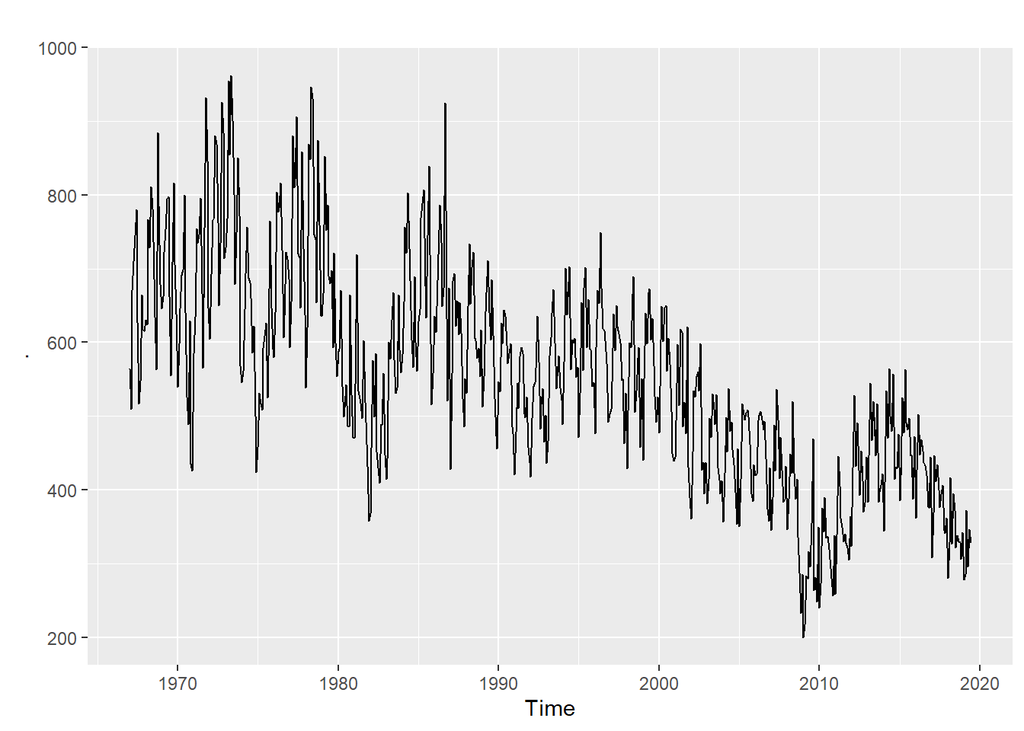

```r
motosale_ts %>%
  autoplot()
```

```r
glimpse(motosale_ts)
```

```
##  Time-Series [1:630] from 1967 to 2019: 564 509 670 710 745 ...
```

# **3.SEASONALITY ANALYSIS**

Before doing the forecasting model, we need to observe the time series object from the `decompose` result. The main idea of decomposition is to describe the three components of the object ts (trend, seasonal, residual).

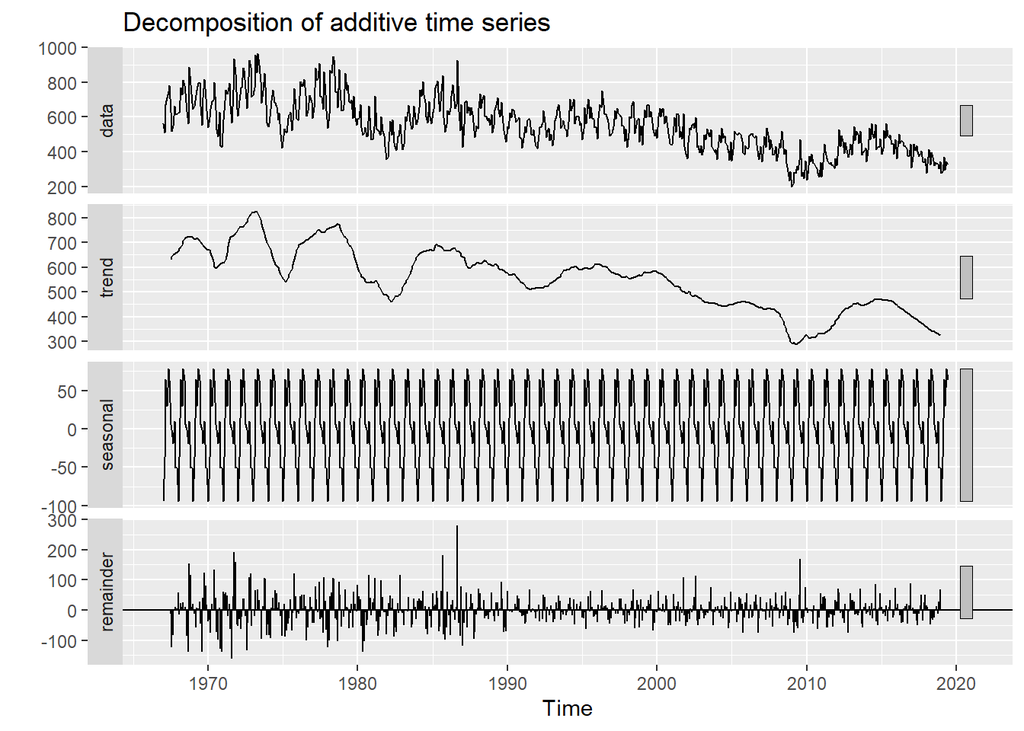

```r
motosale_ts %>%
  decompose() %>%
  autoplot()
```

Based on the results of the decomposition plot above, now We know that the type of time series we have is *additive*.

# **4. MODEL FITTING & EVALUATION**

## **4.1.Cross Validation**

Before doing the time series analysis, we will doing data cross validation by splitting `motosale_ts` into data train and data test.

```r
# data train for 50 years
(motosale_ts_train <- head(motosale_ts, 50*12))
```

```
##          Jan     Feb     Mar     Apr     May     Jun     Jul     Aug     Sep
## 1967 564.100 509.100 670.400 710.200 744.800 780.200 627.200 517.200 547.300
## 1968 630.200 623.700 766.800 728.800 811.000 781.000 736.600 634.500 563.300
## 1969 645.400 662.100 722.300 753.800 794.700 798.100 662.300 555.000 709.400
## 1970 539.200 598.100 646.000 691.300 698.600 800.200 640.900 526.100 488.500
## 1971 584.600 635.000 753.900 734.800 745.700 795.300 666.200 564.800 755.900
## 1972 605.000 692.700 765.700 768.300 880.200 869.300 762.400 650.300 735.100
## 1973 729.000 767.400 954.700 854.400 962.500 900.700 800.900 679.200 748.800
## 1974 545.400 561.500 645.300 693.500 756.600 686.800 681.100 660.000 586.100
## 1975 457.600 530.900 517.000 508.900 592.000 608.400 626.700 525.300 581.800
## 1976 580.100 640.900 804.100 776.800 781.900 816.900 725.900 606.800 637.000
## 1977 592.800 654.700 880.400 809.800 821.300 906.600 720.000 715.200 646.500
## 1978 538.100 619.600 869.200 848.800 947.100 931.300 745.900 740.100 653.700
## 1979 635.600 666.300 852.600 752.800 786.900 690.800 679.600 697.500 592.800
## 1980 588.000 591.500 670.400 541.000 498.700 511.100 542.400 486.800 486.100
```

[output cut: 87 more lines]

```r
# data test for 2 years
(motosale_ts_test <- tail(motosale_ts, 24))
```

```
##          Jan     Feb     Mar     Apr     May     Jun     Jul     Aug     Sep
## 2017                                                 376.212 394.215 406.634
## 2018 280.479 328.988 416.105 326.924 394.895 372.417 321.267 338.095 329.564
## 2019 277.863 285.093 372.433 295.505 346.105 327.864
##          Oct     Nov     Dec
## 2017 345.309 340.959 362.059
## 2018 329.158 306.410 342.587
## 2019
```

## **4.2.Model Fitting & Evaluation**

Since the data having the trend & seasonal. So, We will doing model fitting with `Holtwinters` automatically & manually.

```r
(HWmod_A <- HoltWinters(x = motosale_ts_train,
                                          seasonal = "additive"))
```

```
## Holt-Winters exponential smoothing with trend and additive seasonal component.
##
## Call:
## HoltWinters(x = motosale_ts_train, seasonal = "additive")
##
## Smoothing parameters:
##  alpha: 0.4346224
##  beta : 0.0090972
##  gamma: 0.3273598
##
## Coefficients:
##              [,1]
## a    458.25406181
## b     -0.15374837
## s1  -115.02082013
## s2   -57.96014962
## s3    34.15414076
## s4   -20.28723146
## s5    34.02672743
## s6     0.08182971
## s7   -17.24927712
## s8    18.41107282
## s9   -44.38528371
## s10  -59.31287755
## s11  -78.45111822
## s12  -23.16461175
```

```r
(HWmod_M <- HoltWinters(x = motosale_ts_train,
                                         alpha = 0.01,
                                         beta = 0.001,
                                         gamma = 0.2,
                                         seasonal = "additive"))
```

```
## Holt-Winters exponential smoothing with trend and additive seasonal component.
##
## Call:
## HoltWinters(x = motosale_ts_train, alpha = 0.01, beta = 0.001,     gamma = 0.2, seasonal = "additive")
##
## Smoothing parameters:
##  alpha: 0.01
##  beta : 0.001
##  gamma: 0.2
##
## Coefficients:
##            [,1]
## a    2898.08795
## b       5.49666
## s1  -2343.54992
## s2  -2288.43978
## s3  -2197.63878
## s4  -2253.18654
## s5  -2204.86448
## s6  -2245.77533
## s7  -2273.08019
## s8  -2244.71445
## s9  -2313.84341
## s10 -2331.97370
## s11 -2354.33420
## s12 -2297.99273
```

Then We will do prediction for the model We have create based on the data test.

```r
HWmod_A_fc <- forecast(object = HWmod_A, h = 24)

HWmod_M_fc <- forecast(object = HWmod_M, h = 24)
```

Forecast interpretation.

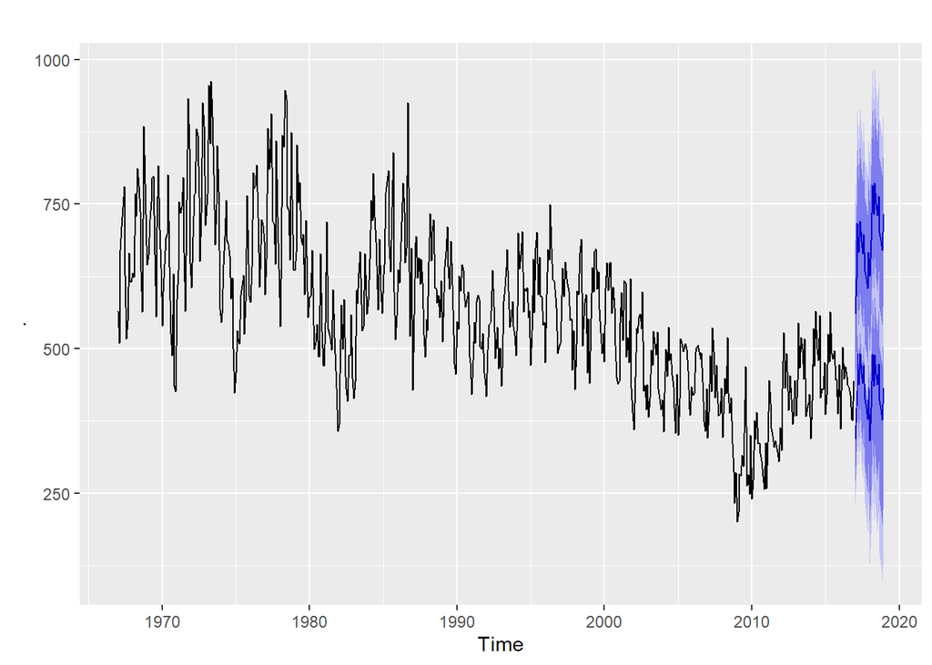

```r
motosale_ts_train %>%
  autoplot() +
  autolayer(object = HWmod_A_fc) +
  autolayer(object = HWmod_M_fc)
```

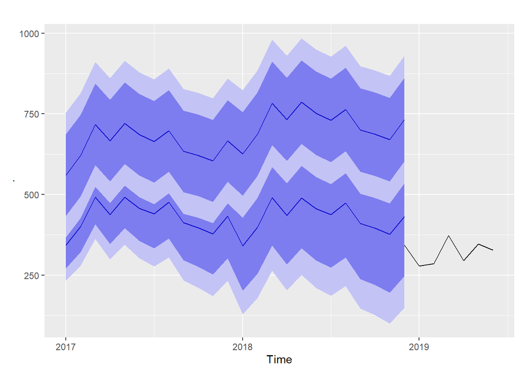

```r
motosale_ts_test %>%
  autoplot() +
  autolayer(object = HWmod_A_fc) +
  autolayer(object = HWmod_M_fc)
```

Model evaluation

```r
forecast::accuracy(HWmod_A_fc$mean, motosale_ts_test)
```

```
##                 ME     RMSE      MAE       MPE     MAPE      ACF1 Theil's U
## Test set -75.56059 80.70608 75.56059 -21.92006 21.92006 0.4272952  1.746043
```

```r
forecast::accuracy(HWmod_M_fc$mean, motosale_ts_test)
```

```
##                 ME     RMSE      MAE       MPE     MAPE      ACF1 Theil's U
## Test set -345.6412 349.9037 345.6412 -100.0839 100.0839 0.7711069  7.584226
```

## **4.3.Compare Model**

Before we decide the model that We will use, We will build another model that compatible to the data and compare which one is better. So, We build another model. Since the data having a trend & seasonal. So, we can not use the Exponential Smoothing model. We will try to build a model using `SARIMA`.

Data staionary check.

```r
motosale_ts_train %>%
  adf.test()
```

```
##
##  Augmented Dickey-Fuller Test
##
## data:  .
## Dickey-Fuller = -4.6672, Lag order = 8, p-value = 0.01
## alternative hypothesis: stationary
```

from `adf.test()` above we can see that the data already stationeer. So, We don’t need to do differencing and We can directly build the model.

```r
(SARIMAmod <- auto.arima(y = motosale_ts_train))
```

```
## Series: motosale_ts_train
## ARIMA(1,0,2)(0,1,2)[12] with drift
##
## Coefficients:
##          ar1      ma1      ma2     sma1     sma2    drift
##       0.9474  -0.3852  -0.1973  -0.6686  -0.1561  -0.4653
## s.e.  0.0176   0.0445   0.0414   0.0410   0.0400   0.2788
##
## sigma^2 = 2819:  log likelihood = -3173.13
## AIC=6360.25   AICc=6360.44   BIC=6390.89
```

Then We will do prediction for the model We have create based on the data test.

```r
SARIMAmod_fc <- forecast(object = SARIMAmod, h = 24)
```

Forecast interpretation.

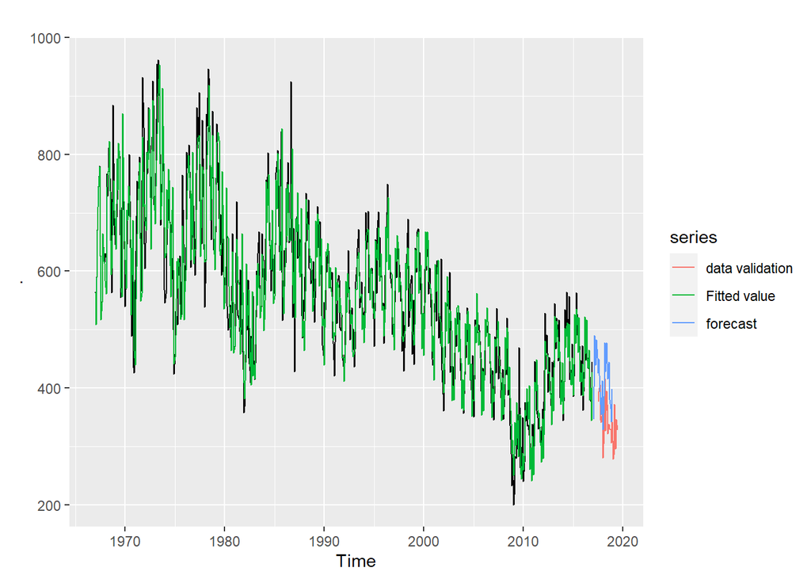

```r
motosale_ts_train %>%
  autoplot() +
  autolayer(object = motosale_ts_test, series = "data validation") +
  autolayer(object = SARIMAmod_fc$mean, series = "forecast") +
  autolayer(object = SARIMAmod$fitted, series = "Fitted value")
```

Model evaluation

```r
forecast::accuracy(SARIMAmod_fc$mean, motosale_ts_test)
```

```
##                 ME    RMSE      MAE       MPE     MAPE      ACF1 Theil's U
## Test set -54.56376 61.8537 55.97338 -15.81701 16.16367 0.5279831  1.325008
```

# **5. CONCLUSION**

From the evaluation of the 3 model that We build, `SARIMA` model is the best result.  
After We know the best model We will use, now we will do **Assumption Check** for the residual.

## **5.1. No-Autocorrelation Residual**

```r
Box.test(SARIMAmod$residuals, type = "Ljung-Box")
```

```
##
##  Box-Ljung test
##
## data:  SARIMAmod$residuals
## X-squared = 0.0064117, df = 1, p-value = 0.9362
```

$H_0$: residual has no-autocorrelation $H_1$: residual has autocorrelation

**p-value > 0.05 (alpha), no-autocorrelation**

**Insight** : residual has no-autocorrelation

## **5.2. Normality Residual**

We will check the normality residual with visualization.

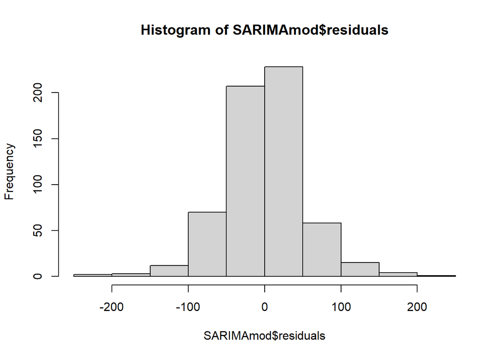

```r
hist(SARIMAmod$residuals)
```

```r
shapiro.test(SARIMAmod$residuals)
```

```
##
##  Shapiro-Wilk normality test
##
## data:  SARIMAmod$residuals
## W = 0.97023, p-value = 1.101e-09
```

H0 : Residual data is normally distributed  
H1 : Residual data is not normally distributed

**Reject H0, if p-value < alpha (0.05)**

**Insight** : Residual data is not normally distributed

## **5.3. Summary**

In a time series, such errors might emerge from various unpredictable events and is actually quite unavoidable. One strategy to overcome it is to analyze what kinds of unpredictable events that might occur and occurs frequently. This can be done by time series analysis using seasonality adjustment.